# Basketball

Nick Bruinsma

12/15/2019

## Overview

For the Capstone final project, I have elected to use a dataset of basketball game statistics. Each player is tracked for each game they have played from 2013 to 2018. Stats like points, steals, rebounds, etc are tracked for each game. The application for a machine learnign algorithm for something like this would be to predict player statistics in upcoming games in order to estimate potential daily fantasy sports points to create a team that is more likely to place in the money.We will focus on the points statistic, since it is the most important indicator of daily fantasy sports performance. We will start by revieiwing the data and doing some linear regression in order to better understand which factors are the most improtant to a predictive model

First we load the data

```r
###Overview

if(!require(tidyverse)) install.packages("tidyverse", repos = "http://cran.us.r-project.org")
if(!require(caret)) install.packages("caret", repos = "http://cran.us.r-project.org")
if(!require(lubridate)) install.packages("lubridate", repos = "http://cran.us.r-project.org")
if(!require(knncat)) install.packages("knncat", repos = "http://cran.us.r-project.org")
if(!require(rpart)) install.packages("rpart", repos = "http://cran.us.r-project.org")
if(!require(rattle)) install.packages("rattle", repos = "http://cran.us.r-project.org")
if(!require(RColorBrewer)) install.packages("RColorBrewer", repos = "http://cran.us.r-project.org")
## Importing packages
library(data.table) # Import big files (CSV or Text)
```

```r
library(readxl) # Import Excel files
library(stringr)
library(lubridate)
library(rpart)
library(rattle)
library(rpart.plot)
library(RColorBrewer)

#Import data of nba players for all games between 2013 and 2018
url <- 'https://github.com/NBruinsma/basketballML/raw/master/basic_per_game_player_stats_2013_2018.csv'
dat <- read.csv(url)
#dat <- read.csv('basic_per_game_player_stats_2013_2018.csv')
```

Clean the data for better use with machine learning algorithms

```r
#clean the data

#Rename the home/away column
colnames(dat)[7]  <- "Home"

#Split the Age into Dates and days
dat  <- dat  %>% separate(Age, c("Age", "Days"), sep = "-")



#Split name and unique identifier
dat  <- dat  %>% separate(Player, c("Player", "Unique ID"), sep = "\\\\")


#get year from date
dat <- dat %>% mutate(Year = as.numeric(str_sub(Date,1,4)))
dat$Date <- as.Date(dat$Date)

#Remove any plyers who don't have at least 10 games worth of data
dat <- dat %>% group_by(Player) %>% filter(n() >=10)


#For when we are going beyond linear regression. We can create success or failure criteria based on the average PTS that would be
#required to be part of a daily fantasy sports team

#With 9 players, trying to reach a score of at least 200 points we would require an average of 22 points per player

dat <- dat %>% mutate(Gr22 = case_when(PTS < 22 ~ 'No', PTS >= 22 ~ 'Yes'))
```

## Analysis

The plan is to split the data into test and train sets, and then we will conduct a linear regression. Once we have a better idea of the data, we will create a decision tree, to try to predict which players will get higher than 22 points (with nine players, that will give us 198 points total).

First we will split up the data into a test and training set. We have a large sample size, so we can create an effective training set with half of the rows

```r
#Split into test and training sets
# test_set set will be 50% of dat data

set.seed(1)

test_index <- createDataPartition(y = dat$PTS, times = 1, p = 0.5, list = FALSE)
train_set <- dat[-test_index,]
temp <- dat[test_index,]

# Make sure all players in test set are also in train set
test_set <- temp %>%
  semi_join(train_set, by = "Player")

# Add rows removed from test_set set back into train_set set

removed <- anti_join(temp, test_set)
```

[output not shown]

```r
train_set <- rbind(train_set, removed)

rm( test_index, temp, removed)



#Remove the points and field goal data from the test_set
test_set_full <- test_set

#Remove points, 2 point attempts, 3 point attemts, 3 point attempts, percentages hit for each variable and field goal attempts and percentage
test_set <- test_set %>% select(-PTS, -X2P, -X3P, -FT, -X2P., -X3P., -FT., -FG., -FGA, Gr22)
```

Next we will explore the data a bit, We will plot some different variables to see if there is a useful relationship between the variable and points to see if it can be used as a predictor We wil check the points distribution and the relationship between points and playing at home or away, player, age, year of game, opponent, etc.

```r
### Analysis

#Determine point distribution
points_dist <- train_set%>%
  group_by(PTS) %>%
  summarize(count = n()) %>%
  arrange(desc(count))

vec_points <- as.vector(train_set$PTS)
unique(vec_points)
```

```
##  [1] 22 20 19 18 15 13 12 11 10  9  8  6  5  4  3  0 32 28 25 24 23 21 17 16 14
## [26]  7  2  1 42 26 33 27 31 30 34 29 45 37 38 35 39 36 43 41 44 54 40 62 51 48
## [51] 61 50 52 57 49 47 46 55 53 56 59 60 58
```

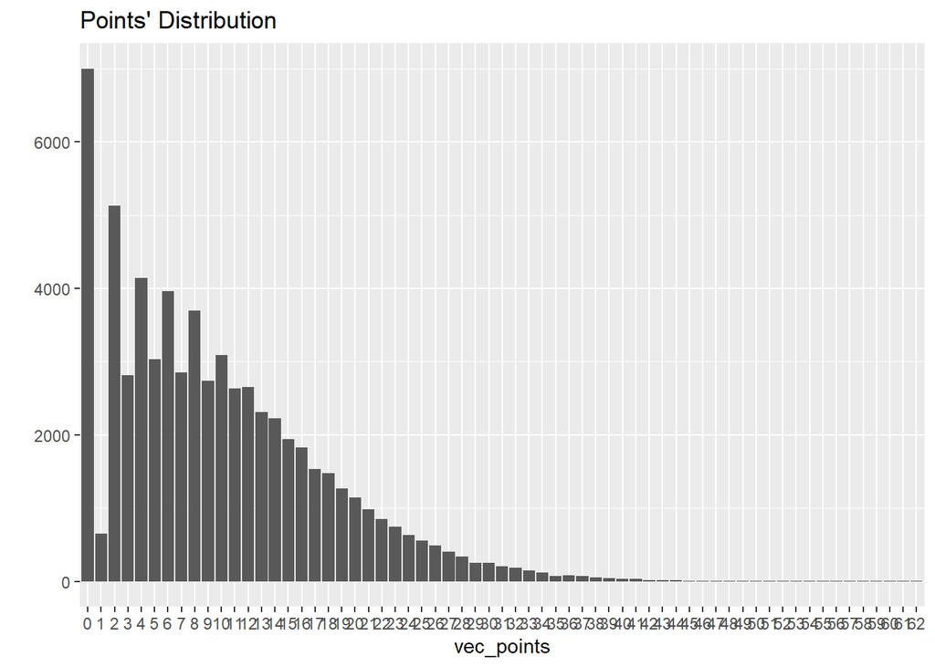

```r
vec_points <- factor(vec_points)
qplot(vec_points) +
  ggtitle("Points' Distribution")
```

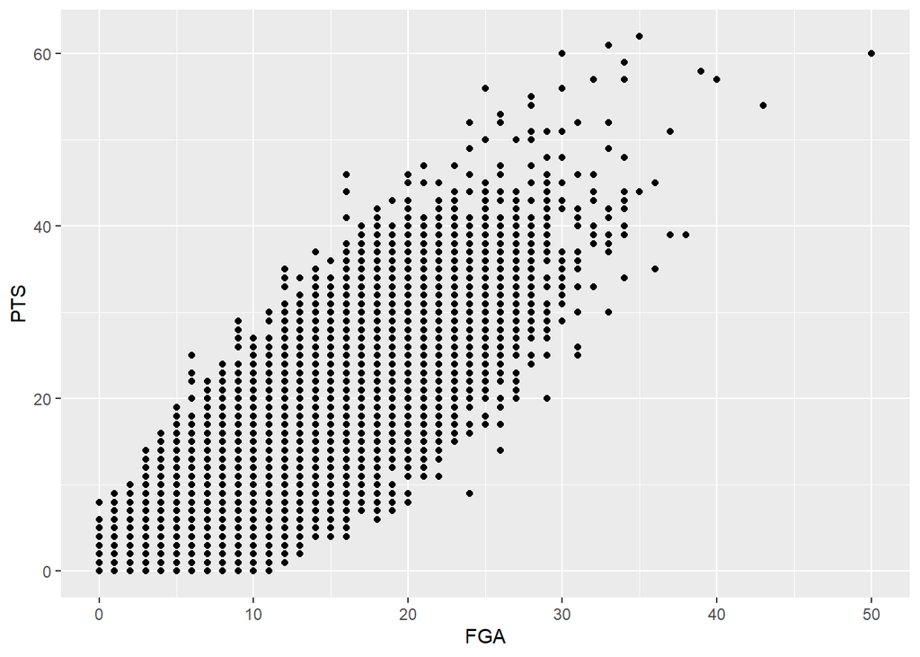

```r
# Field Goal attempts vs points
train_set %>% ggplot(aes(FGA, PTS)) + geom_point()
```

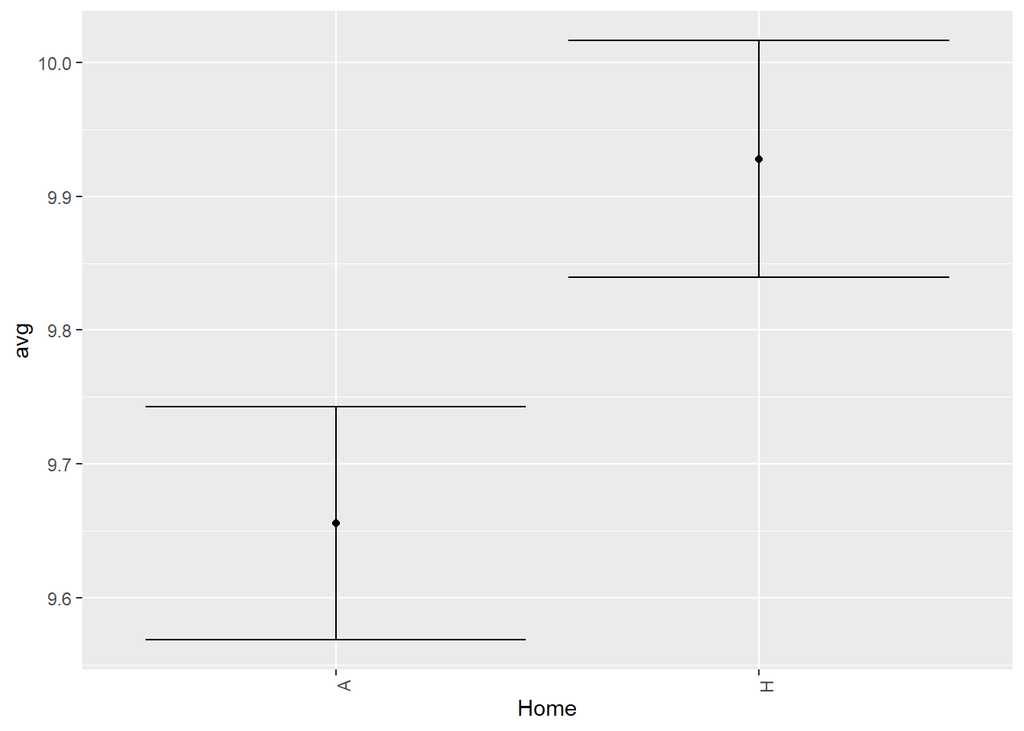

```r
#Not surprisingly, more attempts correlates closely with more points - this is not as useful in predicting points - since we wont know how many attempts in the specific game we are trying to predict points for

# Home average vs away average
train_set %>% group_by(Home) %>% summarize(n = n(), avg = mean(PTS), se = sd(PTS)/sqrt(n()))  %>% mutate(Home = reorder(Home, avg)) %>% ggplot(aes(x = Home, y = avg, ymin = avg - 2*se, ymax = avg + 2*se)) + geom_point() + geom_errorbar() + theme(axis.text.x = element_text(angle = 90, hjust = 1))
```

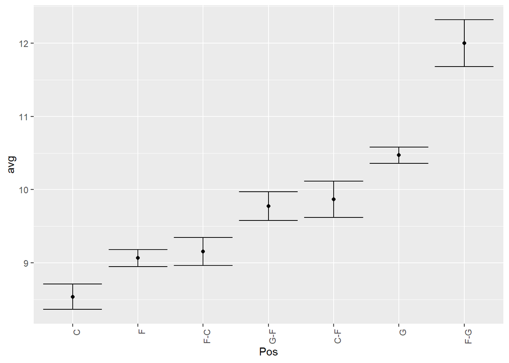

```r
#Home enjoys a slight advantage over away

#Graph points by position
train_set %>% group_by(Pos) %>% summarize(n = n(), avg = mean(PTS), se = sd(PTS)/sqrt(n()))  %>% mutate(Pos = reorder(Pos, avg)) %>% ggplot(aes(x = Pos, y = avg, ymin = avg - 2*se, ymax = avg + 2*se)) + geom_point() + geom_errorbar() + theme(axis.text.x = element_text(angle = 90, hjust = 1))
```

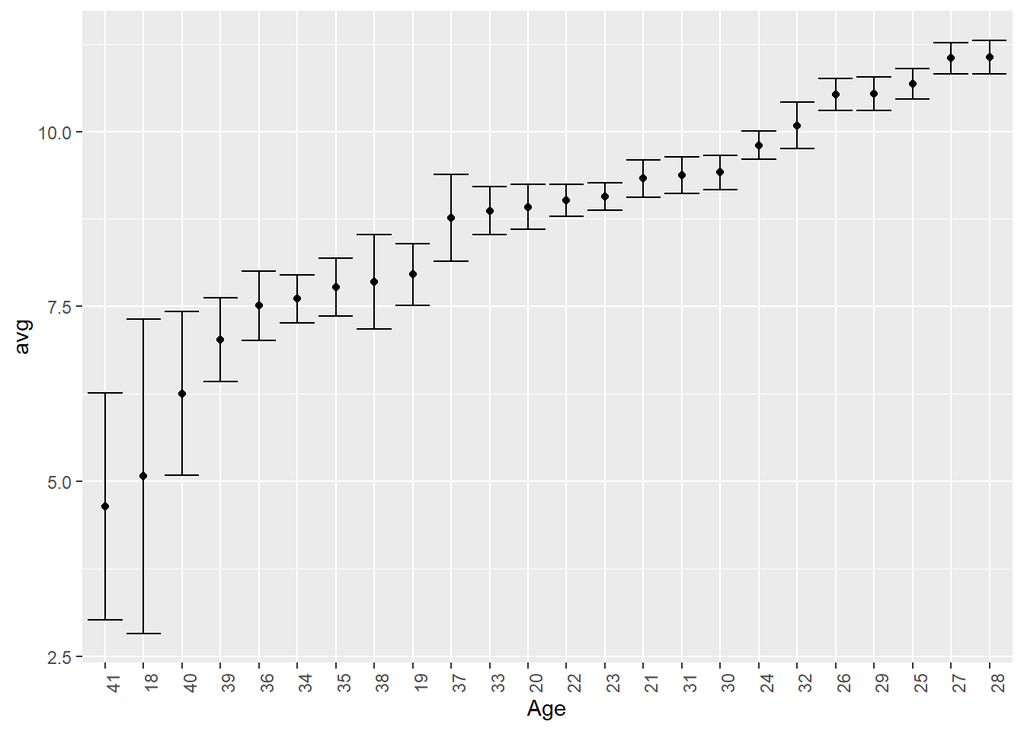

```r
#Certain positions are expected to get more points than others

#Graph points by age
train_set %>% group_by(Age) %>% summarize(n = n(), avg = mean(PTS), se = sd(PTS)/sqrt(n()))  %>% mutate(Age = reorder(Age, avg)) %>% ggplot(aes(x = Age, y = avg, ymin = avg - 2*se, ymax = avg + 2*se)) + geom_point() + geom_errorbar() + theme(axis.text.x = element_text(angle = 90, hjust = 1))
```